# **OBJECTIVE :**

# **`Business Case & Hypothesis`**

## **`With Databricks`**

[figure not shown]

# >>> **Goal:**

## The main purpose to discover impulse purchases for future advertising campaigns.

## To perform it, I will create a deep learning model based on the market segmentation.

## The first task below will be first to get an overview of the data, insights, outliers ...

# **1. Project Overview — Business Context & Objectives**

In this project, I analyze real-world banking transaction data using **Databricks SQL** to extract meaningful insights that support a **future customer segmentation model (deep learning / clustering)**. The goal is to **understand spending behaviors, identify unusual patterns, and generate actionable recommendations**.

The analysis follows a structured data analytics workflow:

> Data exploration & profiling

> Data quality assessment

> Statistical analysis & outlier detection

> Behavioral segmentation using categories & merchant information

> Business interpretation of patterns and anomalies

**This approach mirrors how a Data Analyst or Data Scientist would work in production within a financial institution.**

## **Source : Financial Transactions Dataset (www.Kaggle.com)**

#### Overview : This comprehensive financial dataset combines transaction records, customer information, and card data from a banking institution, spanning across the 2010s decade.

### Dataset Information

#### **1. Transaction Data**

##### * Detailed transaction records including amounts, timestamps, and merchant details

##### * Covers transactions throughout the 2010s

##### * Features transaction types, amounts, and merchant information

##### * Perfect for analyzing spending patterns and building fraud detection models

| Variable | Description |
| --- | --- |
| id | ID number of the transaction |
| date | Transction's date |
| client_id | Client id number |
| card_id | Card id number |
| amount | Amount of the transaction |
| use_chip | Transaction methodology |
| merchant_id | ID munber of the merchant |
| merchant_city | City of the merchant |
| merchant_state | State of the merchant |
| zip | Zip code of the merchant |
| mcc | ID number indicating the category goods or services concerned by the transation |
| errors | Transaction Error |

#### **2. Merchant Category Codes**

##### * Standard classification codes for business types

##### * Enables transaction categorization and spending analysis

##### * Industry-standard MCC codes with descriptions

| Variable | Description |
| --- | --- |
| id | ID number of the category |
| description | Categorie description |

# **2. Data Understanding & Initial Exploration**

**2.1 Loading and Inspecting the Transaction Table**

Before performing any transformations or aggregations, I explore the structure of the dataset:

> Validate column formats (especially the date field)

> Understand the completeness of categorical fields

### **✓ Global view**

1. I queried the number of rows for each table to get a global overview. It appears the transactions_data table (fact table) has over 13 million rows, and the dimension tables (cards_data, mcc_codes, users_data) are small tables.

[figure not shown]

2. I displayed the transactions_data table to determine the correct query format for the column 'date' and then to query the period.

[figure not shown]

3. I checked the period (MAX & MIN) dates of the transactions_data. It appears the transactions_data table has data from 01/01/2010 to 31/10/2019.

[figure not shown]

### **✓ Data Transformation**

I will verify the data type and correct / transform if necessary.

For example below I will:

> a. Delete the $ Symbol

> b. Format the column to decimal number

[figure not shown]

[figure not shown]

# **3. Data Profiling — Statistical Overview**

To understand the **global behaviour** of the dataset, I compute descriptive statistics such as:

> MIN / MAX values

> AVERAGE & MEDIAN amounts

> STANDARD DEVIATION

> EMPTY / NULL values

**Distribution of transactions**

This phase helps reveal:

> extreme or abnormal values

> possible data quality issues

> initial hypotheses regarding the spending behaviour

## 3.1. I want to display the columns with empty values.

For this task, using SQL, I will have to query tables column by column, which can take time.

So I chose to query tables in Databricks from the notebook using Spark.

#### **Below the used Script**

from pyspark.sql.functions import col, lit, count, when, array, struct, explode from functools import reduce

## 1. LIST OF TABLE TO BE VERIFIED

TABLES_TO_VERIFY = [ "workspace.portfolio.cards_data", "workspace.portfolio.mcc_codes", "workspace.portfolio.transactions_data", "workspace.portfolio.users_data" ]

all_results = []

## 2. ANALYSIS

```
try:
    df = spark.table(nom_table_complet)
except Exception as e:
    print(f"WARNING: Error loadind table {nom_table_complet}. Error : {e}")
    continue
```

## 3. CREATION OF NULL_COUNT

```
agg_exprs = [
    count(when(col(c).isNull(), c)).alias(f"null_count_{c}")
    for c in df.columns
]

null_counts_wide_df = df.agg(*agg_exprs)
```

## 4. REPORT CREATION

```
null_counts_long_df = null_counts_wide_df.select(
    explode(array(*[
        struct(lit(c).alias("column_name"), col(f"null_count_{c}").alias("null_count"))
        for c in df.columns
    ])).alias("col_data")
).select(
    col("col_data.column_name"),
    col("col_data.null_count")
).withColumn(
    "table_name", lit(nom_table_complet)
)
```

## 5. FILTER ONLY EMPTY CELLS

```
final_table_results = null_counts_long_df.filter(
    col("null_count") > 0
).select(
    col("table_name"),
    col("column_name"),
    col("null_count")
)

all_results.append(final_table_results)
```

## 6. COMBINE ALL RESULTS

```
if all_results:
  final_report_df = reduce(lambda df1, df2: df1.unionByName(df2), all_results)

  print("\n" + "—" * 50)
  print("REPORT FINAL : COLUMNS WITH MISSING VALUES")
  print("—" * 50)

  final_report_df.display()
else:
  print("\n No missing value found.")
```

[figure not shown]

# **4. Outlier Detection using SQL Statistics**

Using SQL directly in Databricks, I identify transactions that significantly deviate from typical customer behaviour.

Outliers highlight:

> abnormal spending amounts

> categories where clients spend above the median

> potential fraud, exceptional purchases, or high-value segments

**This analysis is essential for building robust segmentation**.

## 4.1. I will search for outliers.

For this task, using SQL, I will use statistics with **MIN / MAX / AVERAGE / STANDARD DEVIATION / MEDIAN**

[figure not shown]

**MIN: **There are negatives values****

MAX: The max is much higher than the average value

MEDIAN: Median < Average -> So the data repartition is much lower than the average. And seeing the MAX is 160 times higher than the average, some data (outliers) are impacting significantly the average.

## 4.2. I will verify the data outliers distribution.

## 1. I will verify the outlier percentage versus the total number of transactions to have an overview. I can see 38% of the transaction amounts are above the average.

[figure not shown]

## 2. Below the detail of the outliers:

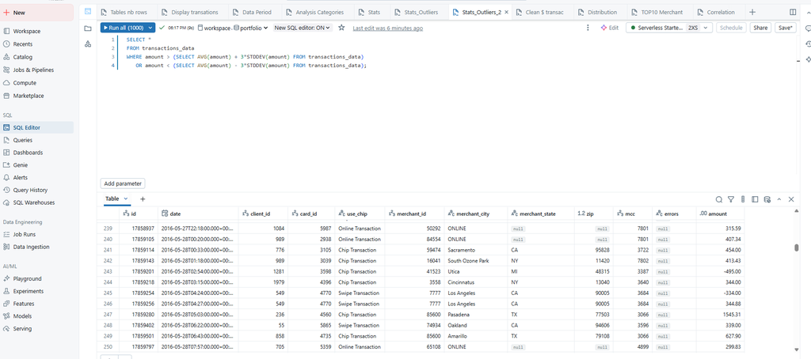

## 3. Focusing on outliers, I then verified the top 10 categories where the transaction amounts are higher than the median amount.

## This query is displaying the categories in which people are able to spend amounts higher than the median (higher than the usual amount). It will be useful for segmentation and deep learning model creation.

[figure not shown]

[figure not shown]

## 4. I will examine the distribution data in the transaction table (based on fields containing 'id' , which are the keys to the 'fact' tables).

### I see there are more than 13 million transactions done on 74K merchants and based only on 1,219 clients.

### I know the dataset is a free dataset downloaded from Kaggle, so I assume the dataset does not contain all values. In case of real-life production, it 's a topic to investigate eventually with data engineers because it seems some data are missing.

[figure not shown]

# **5. Category-Level Analysis**

## 5.1 Weight of Each Spending Category

By joining the transactions_data and grouped_categories tables, I compute the distribution of spending amounts per category and per merchant.

This helps identify:

> the most dominant categories in the dataset

> where customers spend the most

> which categories contribute most to revenue

> early segmentation signals (e.g., travel-heavy, retail-heavy customers)

## **Business Interpretation**

Understanding category weights is key for:

> marketing segmentation

> customer lifetime value modelling

> personalized recommendations

## 5.1. Below, I can see the **TOP10 merchant.**

### It will be interesting to understand the business ( MCC category) of the TOP 3 / TOP 5 . And especially seeing the transaction volume is almost 3 times between the first and second TOP merchant

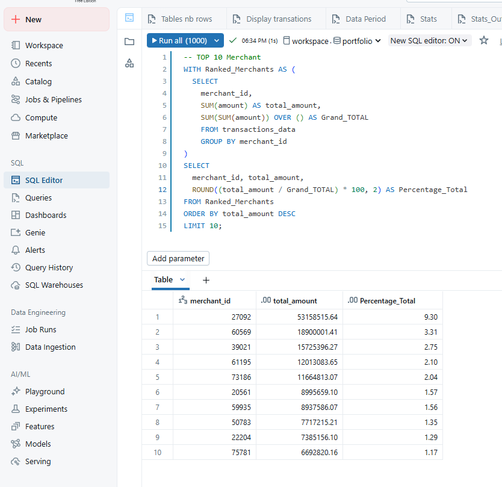

## 5.2. By querying the tables transactions_data and grouped_categories, I can see the weight of each category.

[figure not shown]

## 5.3. By joining transactions_data, users_data and grouped_categories, I queried the transactions by gender and max amount transactions.

## By displaying the max, median , and number of transactions by category and gender, I can easily understand where the outliers are and in which category people are able to spend more.

## It will be useful for the market segmentation deep learning model .

[figure not shown]

### **✓ Data Visualization**

## 5.4. Using the module 'Genie' in Databricks, I obtained a really fast line plot graph of the transactions displayed per month.

[figure not shown]

# **6. Conclusion & Next Steps**

## Outliers which I queried are showing differences on categories.

## Indeed focusing on amount and outliers, I can see that people can spend more on some categories, especially:

1. Travel and Transportation
2. Industrial Materials and Services
3. Clothing and General Shaopping
4. Home Furniture and Decor
5. Creative Hobbies and Supplies

## So the next step is to find based on a first purchase what is probability for the second purchase ?

## In others terms, **based on the first purchase, which can be the impulsive purchase ?**

## To answer this question, then I will create a Deep Learning Model.

## *This project showcases my ability to bridge financial expertise with advanced data engineering tools like Databricks.*

## **Author : Aurelien Legendre**

[figure not shown]